# Número de pasajeros en el Puerto de Barcelona (2012-2019)

Para saber si existe patrón estacional usaremos la función `monthplot`, que calcula la media en cada orden estacional. En nuestro caso, mensualmente.

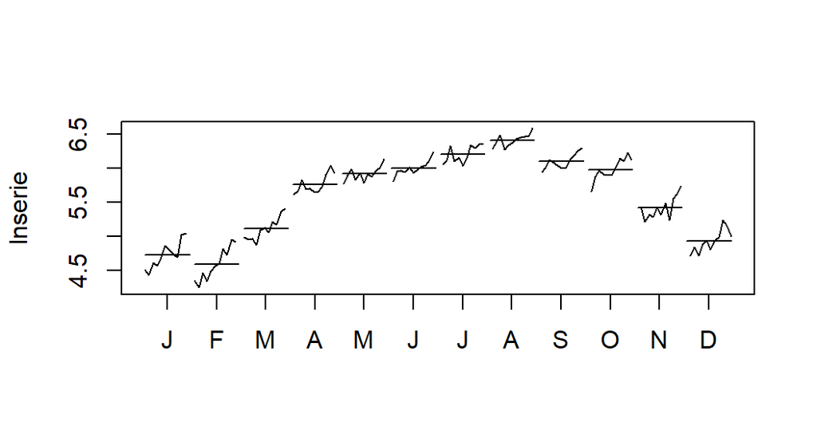

Vemos claramente que hay irregularidades en la media para cada mes, ya que no hay equilibrio en sus líneas horizonales. Por lo que podemos decir que la serie presenta un patrón estacional de orden s=12, como se ha dicho anteriormente. Para poder eliminarlo, se realiza una diferenciación estacional (D = 1), es decir, se restan las observaciones del patrón estacional anterior. Por tanto, se eliminarán S = 12 observaciones, las 12 primeras.

Volvemos a utilizar la función `monthplot` sobre la serie diferenciada estacionalmente para comprobar que se haya eliminado el patrón estacional.

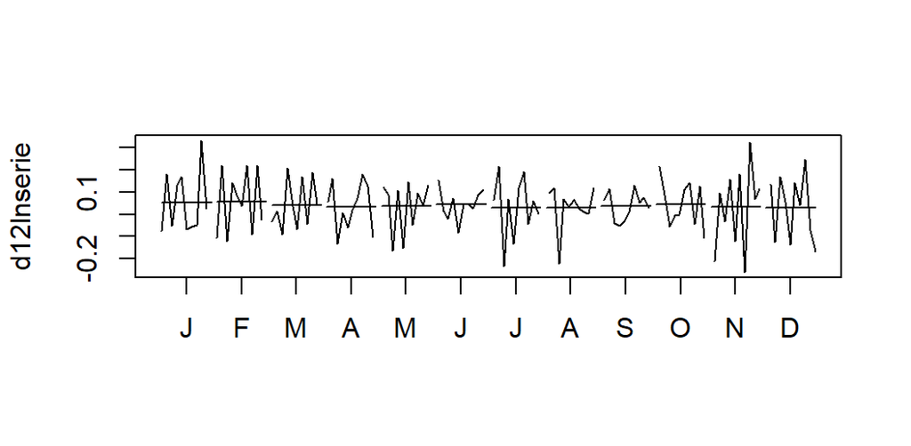

Vemos que, efectivamente, se han estabilizado las medias de cada mes, por lo que podemos afirmar que hemos eliminado el patrón estacional.

**Media constante**

Se obtiene el gráfico temporal de la serie en escala logarítmica y con una diferenciación estacional.

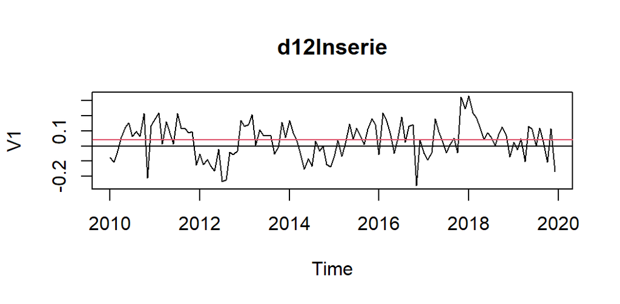

Podemos ver que la media de la serie parece constante pero no llega al valor nulo deseado. Por ello, haremos una diferenciación regular (d=1) y volveremos a graficar la serie para verificar que es 0.

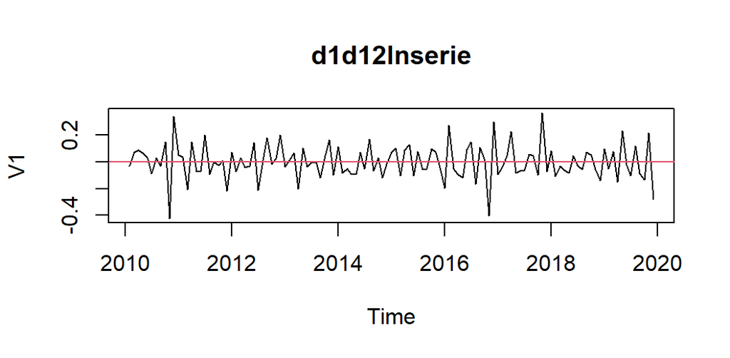

Ahora podemos ver como la media sí tiene valor nulo pero para comprobar que la serie no presenta sobrediferenciación compararemos las varianzas de las tres transformaciones.

```
##          V1
## V1 0.378022
```

```
##            V1
## V1 0.01363138
```

```
##            V1
## V1 0.01699842
```

| Modelo | lnserie | d12lnserie | d1d12lnserie |
| --- | --- | --- | --- |
| Varianza | 0.378022 | 0.0136314 | 0.0169984 |

Se observa que la segunda serie presenta una menor varianza pero no se aleja significativamente de la tercera y, como deseábamos tener un valor nulo de la media, nos quedamos con esta.

### Identificación de modelos pausibles

Para identificar algunos modelos graficamos el ACF y el PACF de la serie estacionaria. En el siguiente gráfico se muestra en color rojo los “s” rezagos estacionales de la función (P)ACF. En negro, todos los rezagos regulares.

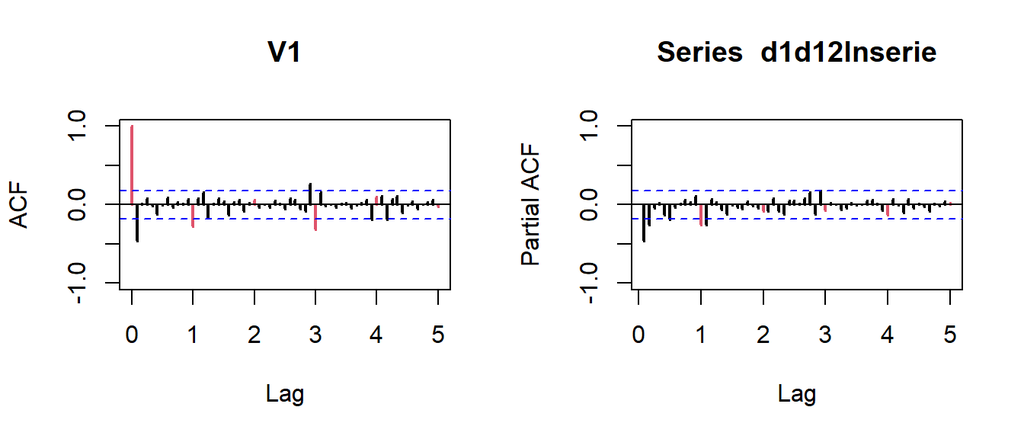

Podemos confirmar que se ha llegado a la serie estacionaria ya que los valores de ACF disminuyen hacia el 0.

Observando las gráficas se concluye que:

- *Opciones para la parte regular*: MA(1), AR(2)
- *Opciones para la parte estacional*: SMA(1), SAR(1) con S=12

Todas ellas con las diferenciaciones aplicadas, una regular (d = 1) y otra estacional (D = 1 con S = 12).

Así pues, se obtienen 4 posibles combinaciones, 4 modelos propuestos.

### Forma compacta y usando el operador de retardo B de los modelos identificados

$W_t = (1-B)^d(1-B^S)^D ln(W_t)$

$MA(1)SMA(1)_{12}$ para $W_t$

Forma compacta de modelo ARIMA para $ln(X_t)$

$(1-B)(1-B^{12}) ln(X_t) = \theta_1(B)\Theta_1(B^{12})Z_t, d = 1,\; y \; D = 1 \; con \; S = 12$

Sustituyendo cada polinomio característico se obtiene:

$(1-B)(1-B^{12}) ln(X_t) = (1+\theta_1B)(1+\Theta_1B^{12})Z_t$

$AR(2)SMA(1)_{12}$ para $W_t$

Forma compacta de modelo ARIMA para $ln(X_t)$

$\phi_2(B) (1-B)(1-B^{12}) ln(X_t) = \Theta_1(B^{12})Z_t, d = 1,\; y \; D = 1 \; con \; S = 12$

Sustituyendo cada polinomio característico se obtiene:

$(1-\phi_1B-\phi_2B^2)(1-B)(1-B^{12}) ln(X_t) = (1+\Theta_1B^{12})Z_t$

$MA(1)SAR(1)_{12}$ para $W_t$

Forma compacta de modelo ARIMA para $ln(X_t)$

$(1-\Phi_1B^{12})(1-B)(1-B^{12}) ln(X_t) =\theta_1(B)Z_t, d = 1,\; y \; D = 1 \; con \; S = 12$

Sustituyendo cada polinomio característico se obtiene:

$(1-\Phi_1B^{12})(1-B)(1-B^{12}) ln(X_t) = (1+\theta_1B)Z_t$

$AR(2)SAR(1)_{12}$ para $W_t$

Forma compacta de modelo ARIMA para $ln(X_t)$

$\phi_2(B)(1-\Phi_1B^{12})(1-B)(1-B^{12}) ln(X_t) = Z_t, d = 1,\; y \; D = 1 \; con \; S = 12$

Sustituyendo cada polinomio característico se obtiene:

$(1-\phi_1B-\phi_2B^2)(1-\Phi_1B^{12})(1-B)(1-B^{12}) ln(X_t) = Z_t$

## Estimación de los modelos

### Modelo 1A, MA(1)SMA(1)$_{12}$

Se impone a la serie estacional `d1d12lnserie` el modelo identificado: ARIMA(0, 0, 1)(0, 0, 1)$_{12}$.

Se calculan los T-ratios para cada coeficiente para ver cuáles son estadísticamente significativos:

```
## Modelo 1a
##  T-ratios: -7.14 -6.58 -0.03
```

El T-ratio del `intercept` es menor a 2, así que se plantea el modelo sin este coeficiente.

### Modelo 1B, usando la serie no-estacionaria $ln(X_t)$ (lnserie)

Se elimina el coeficiente `intercept`, estimando el modelo con la serie original en logaritmos (sin aplicar ninguna diferenciación).

Se calculan los T-ratios para cada coeficiente para ver cuáles son estadísticamente significativos:

```
## Modelo 1b
## T-ratios: -7.14 -6.59
```

Todos los coeficientes son estadísticamente significativos, no es necesario eliminar nada más. Se calcula el AIC de los modelos con y sin `intercept` para saber cuál de ellos tiene un valor menor de esta medida.

| Modelo | AIC |
| --- | --- |
| Con `intercept` | -203.7712101 |
| Sin `intercept` | -205.7718431 |

### Modelo 2A, AR(2)SMA(1)$_{12}$

Se impone a la serie estacional `d1d12lnserie` el modelo identificado: ARIMA(2, 0, 0)(0, 0, 1)$_{12}$

Se calculan los T-ratios para cada coeficiente para ver cuáles son estadísticamente significativos:

```
## Modelo 2a
## T-ratios: -6.64 -2.35 -5.95 -0.04
```

El T-ratio del `intercept` es menor a 2, así que se plantea el modelo sin este coeficiente.

### Modelo 2B, usando la serie no-estacionaria $ln(X_t)$ (lnserie)

Se elimina el coeficiente `intercept`, estimando el modelo con la serie original en logaritmos (sin ninguna diferenciación).

Se calculan los T-ratios para cada coeficiente para ver cuáles son estadísticamente significativos:

```
## Modelo 2b
## T-ratios: -6.64 -2.35 -5.95
```

Todos los coeficientes son estadísticamente significativos, no es necesario eliminar nada más. Se calcula el AIC de los modelos con y sin `intercept` para saber cuál de ellos tiene un valor menor de esta medida.

| Modelo | AIC |
| --- | --- |
| Con `intercept` | -199.1634482 |
| Sin `intercept` | -201.1625283 |

### Modelo 3A, MA(1)SAR(1)$_{12}$

Se impone a la serie estacional `d1d12lnserie`el modelo identificado: ARIMA(0, 0, 1)(1, 0, 0)$_{12}$

Se calculan los T-ratios para cada coeficiente para ver cuáles son estadísticamente significativos:

```
## Modelo 3a
## T-ratios: -7.26 -4.51 -0.15
```

El T-ratio del `intercept` es menor a 2, así que se plantea el modelo sin este coeficiente.

### Modelo 3B, usando la serie no-estacionaria $ln(X_t)$ (lnserie)

Se calculan los T-ratios para cada coeficiente para ver cuáles son estadísticamente significativos:

```
## Modelo 3b
## T-ratios: -7.27 -4.5
```

No es necesario eliminar nada más. Se calcula el AIC de los modelos con y sin `intercept`, para saber cuál de ellos tiene un menor valor de esta medida.

| Modelo | AIC |
| --- | --- |
| Con `intercept` | -195.9228906 |
| Sin `intercept` | -197.9027586 |

En este caso, es mejor el modelo sin `intercept`, aunque la diferencia entre ambos modelos es muy pequeña.

### Modelo 4A, AR(2)SAR(1)$_{12}$

Se impone a la serie estacional `d1d12lnserie` el modelo identificado: ARIMA(2, 0, 0)(1, 0, 0)$_{12}$

Se calculan los T-ratios para cada coeficiente para ver cuáles son estadísticamente significativos:

```
## Modelo 4a
## T-ratios: -7.04 -2.61 -4.47 -0.09
```

El T-ratio del `intercept` es menor a 2, así que se plantea el modelo sin este coeficiente.

### Modelo 4B, usando la serie no-estacionaria $ln(X_t)$ (lnserie)

Se calculan los T-ratios para cada coeficiente para ver cuáles son estadísticamente significativos:

```
## Modelo 4b
## T-ratios: -7.04 -2.61 -4.47
```

No es necesario eliminar nada más. Se calcula el AIC de los modelos con y sin `intercept`, para saber cuál de ellos tiene un menor valor de esta medida.

| Modelo | AIC |
| --- | --- |
| Con `intercept` | -192.8037495 |
| Sin `intercept` | -194.7956946 |

En este caso, es mejor el modelo sin `intercept`, aunque la diferencia entre ambos modelos es muy pequeña.

### Tabla resumen

Realizamos una tabla resumen para los cuatro modelos definitivos con el objetivo de poder ver de forma más clara la comparación entre ellos.

```
##
## Results
## =============================================================
##                               Dependent variable:
##                   -------------------------------------------
##                                  d1d12lnserie
##                       1A         2A         3A         4A
##                      (1)        (2)        (3)        (4)
## -------------------------------------------------------------
## ma1               t = -7.136            t = -7.262
##                     -0.673                -0.679
##
## ar1                          t = -6.641            t = -7.038
##                                -0.614                -0.642
##
## ar2                          t = -2.347            t = -2.611
##                                -0.220                -0.239
##
## sma1              t = -6.585 t = -5.949
##                     -0.620     -0.593
##
## sar1                                    t = -4.506 t = -4.468
##                                           -0.407     -0.404
##
## intercept         t = -0.027 t = -0.044 t = -0.146 t = -0.093
##                    -0.00004   -0.0001    -0.0003    -0.0003
##
## -------------------------------------------------------------
## Observations         119        119        119        119
## Log Likelihood     105.886    104.582    101.961    101.402
## sigma2              0.009      0.010      0.010      0.010
## Akaike Inf. Crit.  -203.771   -199.163   -195.923   -192.804
## =============================================================
## Note:                 t = T-statistic value = coeff/SE(coeff)
```

En la tabla anterior se observan las estimaciones y los T-ratios de los coeficientes de los 4 modelos estimados. Antes de proceder a la explicación, se recuerda a que hace referencia cada uno de ellos:

- Modelo 1: $MA(1)SMA(1)_{12}$
- Modelo 2: $AR(2)SMA(1)_{12}$
- Modelo 3: $MA(1)SAR(1)_{12}$
- Modelo 4: $AR(2)SAR(1)_{12}$
- Modelos A: estimación con la serie estacionaria
- Modelos B: estimación con la serie NO estacionaria

Como se deseaba, todos los T-ratios son mayores de 2, excepto los que hacen refererencia al `intercept` de la serie estacionaria. Se concluye que todos los coeficientes son necesarios para explicar los datos.

Observando el críterio del AIC, se puede decir que los mejores modelos son aquellos que tienen un valor menor en esta medida de calidad relativa. Así pues, a partir de ahora, solo se seguirán estudiando los modelos 1A y 2A ya que son estos los que tienen un valor más negativo.

# Validación de los modelos ajustados

Para validar los modelos propuestos, seguiremos los siguientes pasos:

-> Verificaremos que los residuos tengan varianza constante y se distribuyan de manera normal e independiente. -> Revisaremos el ACF (autocorrelación) y PACF (autocorrelación parcial) de los residuos para asegurarnos de que se - distribuyen como un “ruido blanco”, es decir, sin patrones o dependencias. -> Aseguraremos que el modelo sea causal e invertible.

## Validación modelo 1A

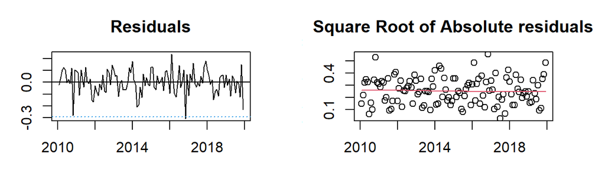

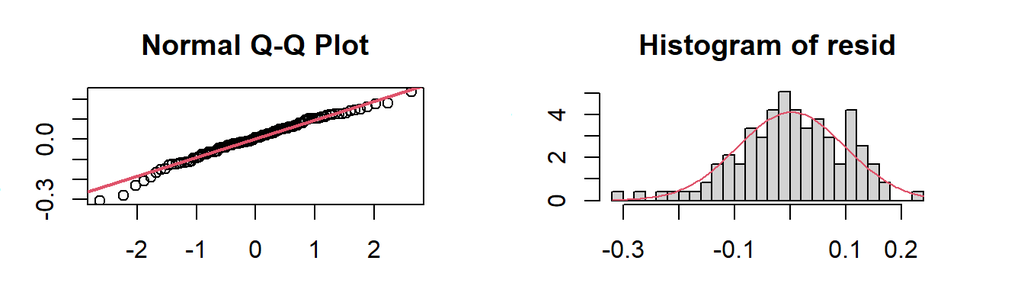

*Residuals:* Los residuos parecen estar distribuidos de manera aleatoria y la mayoría se encuentra dentro de los límites de confianza establecidos. Además, los residuos se centran en torno a cero, lo que indica que el modelo está haciendo predicciones precisas.

*Square Root of Absolute residuals:* La línea roja en el gráfico de los residuos es constante, lo que sugiere que la varianza también es constante

*Normal QQ-Plot:* Hay algunos valores atípicos en las colas.

*Histogram of resid:* Parece que hay algunos valores atípicos en los datos y la distribución presenta kurtosis, lo que significa que no se ajusta del todo a una distribución normal. La presencia de outliers puede estar contribuyendo a la kurtosis, y la distribución tiende a ser asimétrica y a inclinarse hacia la derecha.

*Conclusión:* Parece que la varianza es constante y hay presencia de atípicos en los residuos.

Realizamos el test de Breusch-Pagan y contrastamos las siguientes hipótesis:

- $H_0$: Los residuos son homocedasticos
- $H_1$: Los residuos no son homocedasticos

Obtenemos un p-valor superior a 0.05, así que afirmamos que los residuos son homocedasticos.

Realizamos los tests de Shapiro-Wilk, Anderson-Darling y Jarque Bera y contrastamos las siguientes hipótesis:

- $H_0$: Los residuos son normales
- $H_1$: Los residuos no son normales

Después de realizar los tests de normalidad, obtuvimos p-valores superiores a 0.05, lo que nos permite afirmar que los residuos se distribuyen de manera normal. Es importante tener en cuenta que estos tests son muy sensibles a la presencia de valores atípicos, por lo que es posible que los resultados no sean del todo precisos. Por esta razón, también es útil examinar el gráfico QQ-plot, donde se puede ver que los residuos centrales sí cumplen con la normalidad, pero los que pertenecen a las colas no. Esto sugiere que es necesario prestar especial atención a los valores atípicos y tratar de identificarlos y eliminarlos para mejorar la precisión del modelo.

Contrastamos hipótesis:

*Durbin-Watson test*

-> $H_0$: No hay autocorrelación en los residuos en el retardo k -> $H_1$: Hay autocorrelación en los residuos en el retardo k

Se obtiene un p-valor superior a 0.05, así que afirmamos que no hay autocorrelación en los residuos.

*Ljung-Box test*

-> $H_0$: No hay autocorrelación hasta el retardo k -> $H_1$: Hay autocorrelación hasta el retardo k

Después de realizar los tests de autocorrelación, obtuvimos un p-valor superior a 0.05 en el retardo (lag) 36. Esto significa que, según el programa utilizado, al menos hasta el retardo 48 no hay una estructura de autocorrelación evidente en los datos. Esto es una buena señal, ya que la autocorrelación puede afectar la precisión del modelo y es importante asegurarse de que los datos no tengan patrones de dependencia

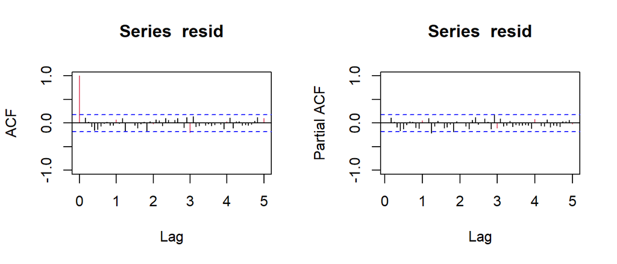

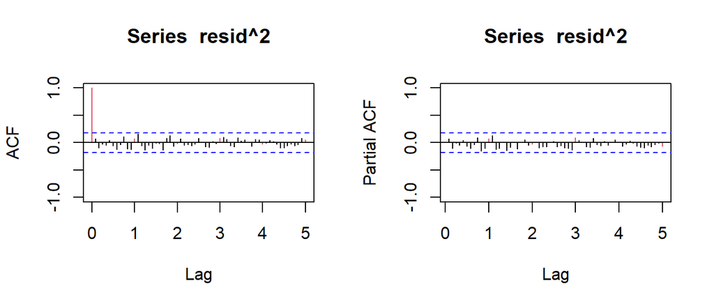

Los gráficos ACF (autocorrelación) y PACF (autocorrelación parcial) de los residuos nos permiten visualizar la dependencia entre los datos y nos dan una idea de si hay autocorrelación presente. Al examinar estos gráficos, observamos que todos los retardos se encuentran dentro de las bandas de confianza, lo que nos permite reafirmar el resultado obtenido en el test de Durbin-Watson: no hay autocorrelación en los residuos.

## Validación modelo 2A

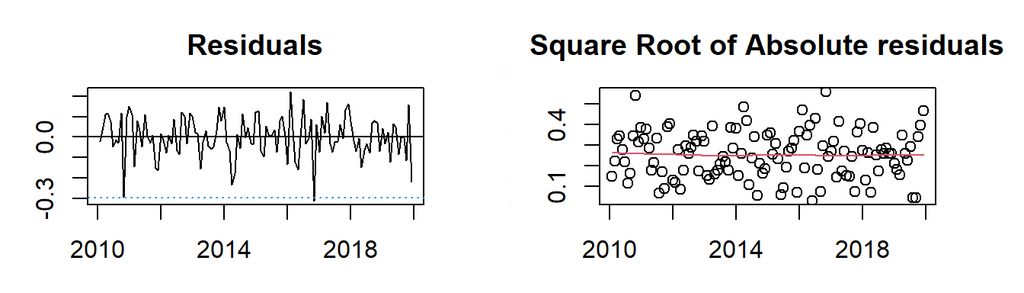

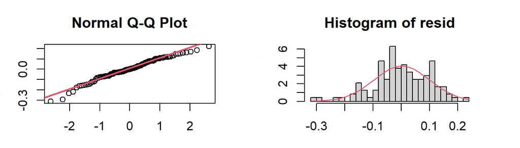

*Residuals:* Los residuos parecen estar distribuidos de manera aleatoria y la mayoría se encuentra dentro de los límites de confianza establecidos. Además, los residuos se centran en torno a cero, lo que indica que el modelo está haciendo predicciones precisas

*Square Root of Absolute residuals:* La línea roja en el gráfico de los residuos es ligeramenteconstante, lo que sugiere que la varianza también es constante

*Normal QQ-Plot:* Hay algunos valores atípicos en las colas.

**Histogram of resid:** Parece que hay algunos valores atípicos presentes en los datos, especialmente en la cola izquierda. Además, la parte central de los datos no se ajusta bien a una distribución normal, ya que los datos están desplazados hacia la izquierda.

*Conclusión:* Parece que la varianza es constante y hay presencia de atípicos en los residuos.

A continuación se realiza el test de Breusch-Pagan y se contrastan las siguientes hipótesis:

- $H_0$: Los residuos son homocedasticos
- $H_1$: Los residuos no son homocedasticos

Se obtiene un p-valor superior a 0.05, así que se afirma que los residuos son homocedasticos.

A continuación se realizan los tests de Shapiro-Wilk, Anderson-Darlin y Jarque Bera y se contrastan las siguientes hipótesis:

- $H_0$: Los residuos son normales
- $H_1$: Los residuos no son normales

Después de realizar los tests de normalidad, obtuvimos p-valores superiores a 0.05, lo que nos permite afirmar que los residuos se distribuyen de manera normal. Es importante tener en cuenta que estos tests son muy sensibles a la presencia de valores atípicos, por lo que es posible que los resultados no sean del todo precisos.

Por esta razón, también es útil examinar el gráfico QQ-plot, donde se puede ver que los residuos centrales sí cumplen con la normalidad, pero los que pertenecen a las colas no. Esto sugiere que es necesario prestar especial atención a los valores atípicos y tratar de identificarlos y eliminarlos para mejorar la precisión del modelo.

Contrastamos hipótesis:

*Durbin-Watson test*

-> $H_0$: No hay autocorrelación en los residuos en el retardo k -> $H_1$: Hay autocorrelación en los residuos en el retardo k

Se obtiene un p-valor superior a 0.05, así que se afirma que no hay autocorrelación en los residuos.

*Ljung-Box test*

-> $H_0$: No hay autocorrelación hasta el retardo k -> $H_1$: Hay autocorrelación hasta el retardo k

Se obtiene un p-valor superior a 0.05 en el retardo (lag) 36. Tal y como está programada la función significa que como mínimo hasta el retardo 48 no hay una estructura de autocorrelación.

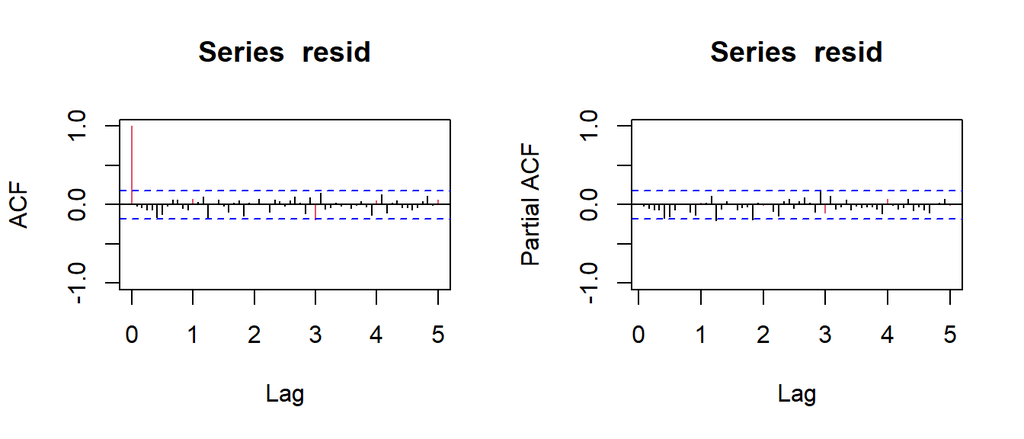

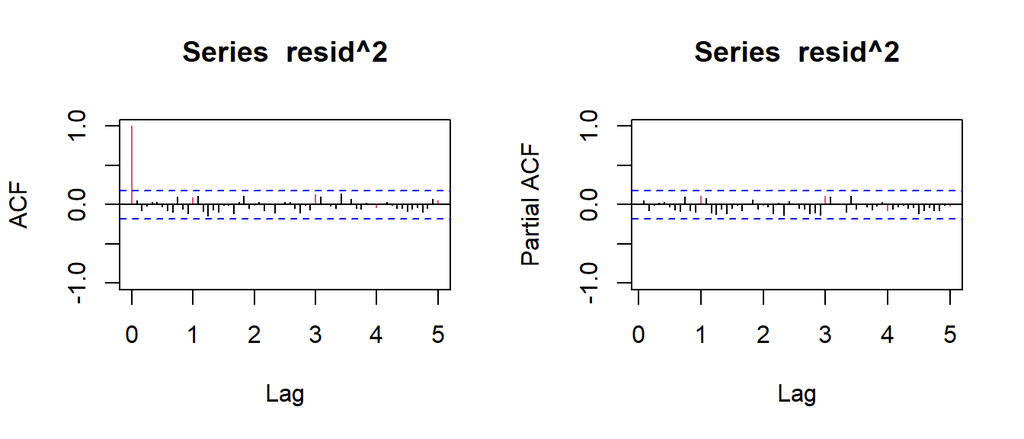

Los gráficos ACF (autocorrelación) y PACF (autocorrelación parcial) de los residuos nos permiten visualizar la dependencia entre los datos y nos dan una idea de si hay autocorrelación presente. Al examinar estos gráficos, observamos que casi todos los retardos se encuentran dentro de las bandas de confianza, lo que nos permite reafirmar el resultado obtenido en el test de Durbin-Watson: no hay autocorrelación en los residuos.

# Predicción de modelos ARIMA ajustados y validados

## Modelo 1A

### Verificación estabilidad del modelo

Para evaluar la estabilidad del modelo, se ha excluido el último año de datos y se ha creado un nuevo modelo. Si el modelo es estable, esperaríamos que los coeficientes estimados obtenidos con la serie completa y con la serie incompleta sean similares. Por “similares” nos referimos a que tienen la misma magnitud, el mismo signo y la misma significancia.

```
##
## Call:
## arima(x = lnserie1, order = c(0, 0, 1), seasonal = list(order = c(0, 0, 1),
##     period = 12))
##
## Coefficients:
##          ma1    sma1  intercept
##       0.7434  0.7568     5.5935
## s.e.  0.0501  0.0643     0.0669
##
## sigma^2 estimated as 0.06835:  log likelihood = -15.69,  aic = 39.38
```

```
##
## Call:
## arima(x = lnserie2, order = c(0, 0, 1), seasonal = list(order = c(0, 0, 1),
##     period = 12))
##
## Coefficients:
##          ma1    sma1  intercept
##       0.7256  0.7989     5.5776
## s.e.  0.0548  0.0833     0.0699
##
## sigma^2 estimated as 0.06655:  log likelihood = -14.1,  aic = 36.19
```

El modelo es estable pues se cumplen las 3 condiciones establecidas.

### Predicción out-of-sample y cálculo RMSPE/MAPE

A continuación se grafica la serie completa **(sin dejar el último año fuera)** y se hace una predicción del último año para ver si el modelo estima correctamente los datos.

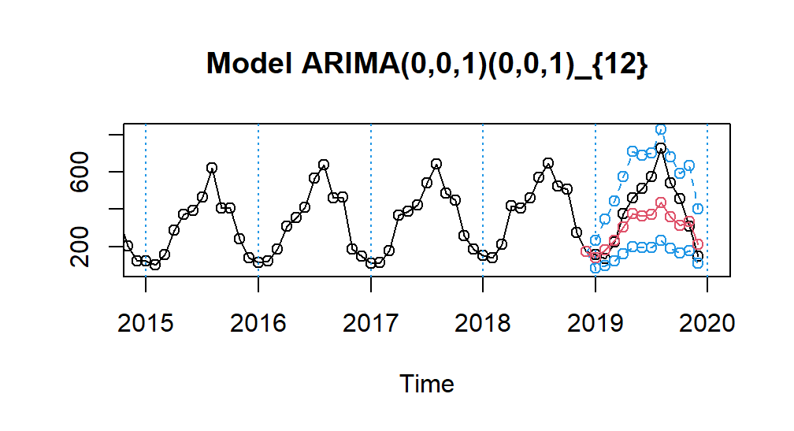

El modelo propuesto estima de manera regular los datos (estimación en color rojo). Aunque, los datos reales se encuentran dentro de las bandas de confianza (estimaciones en color azul).

**Cálculo de medidas RMSPE/MAPE y mean Length**

| Medida | Valor |
| --- | --- |
| EQM | 0.284744 |
| EAM | 0.2565645 |

## Modelo 2A

### Verificación estabilidad del modelo

Para comprobar si el modelo es estable se usa el mismo criterio explicado en el modelo 1A.

```
##
## Call:
## arima(x = lnserie1, order = c(2, 0, 0), seasonal = list(order = c(0, 0, 1),
##     period = 12))
##
## Coefficients:
##          ar1      ar2    sma1  intercept
##       1.2323  -0.5443  0.5923     5.5814
## s.e.  0.0778   0.0782  0.0603     0.0890
##
## sigma^2 estimated as 0.04299:  log likelihood = 16.92,  aic = -23.84
```

```
##
## Call:
## arima(x = lnserie2, order = c(2, 0, 0), seasonal = list(order = c(0, 0, 1),
##     period = 12))
##
## Coefficients:
##          ar1      ar2    sma1  intercept
##       1.2176  -0.5335  0.6152     5.5682
## s.e.  0.0809   0.0813  0.0660     0.0926
##
## sigma^2 estimated as 0.04256:  log likelihood = 15.42,  aic = -20.85
```

El modelo es estable pues se cumplen las 3 condiciones establecidas.

### Predicción out-of-sample y cálculo RMSPE/MAPE

A continuación, se ha graficado la serie completa de datos (sin excluir el último año) y se ha realizado una predicción para el último año para evaluar si el modelo estima correctamente los datos. Esto nos permite determinar si el modelo es adecuado para hacer predicciones y si es capaz de captar los patrones presentes en los datos.

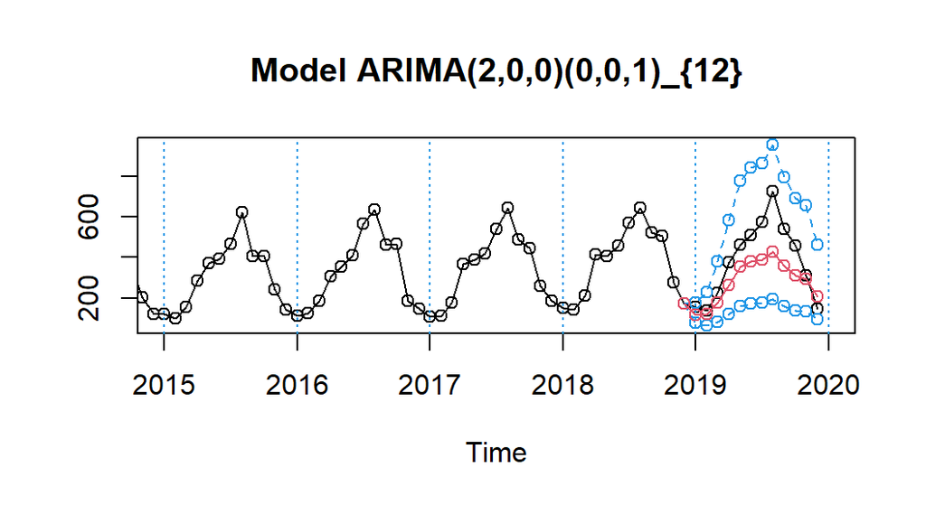

Igual que en el modelo 1A, la estimación no es muy cercana a los valores reales pero las bandas de confianza ajustan bien los datos reales.

**Cálculo de medidas RMSPE/MAPE y mean Length**

| Medida | Valor |
| --- | --- |
| EQM | 0.2861041 |
| EAM | 0.2673542 |

# Selección del mejor modelo

Después de validar los modelos y analizar sus capacidades predictivas, es necesario elegir un solo modelo para llevar a cabo el objetivo principal del estudio, que es la realización de predicciones a largo plazo.

Para tomar esta decisión, es importante comparar las medidas de adecuación a los datos (AIC) y sus capacidades de predicción, dando más peso a estas últimas.

Es necesario crear una tabla que incluya los valores más relevantes para poder comparar los dos modelos propuestos y seleccionar el mejor. Esto nos permitirá utilizar el modelo seleccionado para hacer predicciones precisas y confiables a largo plazo.

[output not shown]

En cuanto a la medida de adecuación a los datos, se observa que el modelo 1A es preferible al 2A, ya que éste tiene un AIC menor. Para la capacidad predictiva realmente no importa qual escogamos ya que el error es de 28% en el caso del EQM y un 25% en EAM. Sin embargo, respecto el EAM, el mod2A lo tiene un 1% superior por lo tanto es mejor el modelo 1A. Cabe destacar que ambos modelos tienen un error en la capacidad predictiva superior al 25%, por lo que se concluye que los dos son bastante regulares. Además, existe otra medida comparable entre modelos: la amplitud de la predicción. Este valor, interesa que sea pequeño, pues querrá decir que el intervalo de confianza de los valores predichos estará más acotado, será más estrecho. Observando la tabla anterior, se puede decir que el modelo 1A tiene una amplitud de predicción bastante menor que la del modelo 2A.

Así pues, después de toda esta explicación, se concluye que el mejor modelo para realizar la predicción a largo plazo es el modelo 1A, ya que es el que tiene menor AIC y menor amplitud de predicción.

Antes de pasar a realizar la predicción, es necesario recordar la expresión del modelo elegido. Esta era la siguiente: $MA(1)SMA(1)_{12}$.

### Realización predicción a largo plazo

Una vez que se ha seleccionado el mejor modelo, es hora de hacer la predicción. Para llevarla a cabo, se utilizan los valores de la serie completa y se estima cuántos pasajeros habría habido en el puerto de Barcelona en el año 2020 si no se hubiera producido la pandemia del Covid-19.

Esto nos permite obtener una idea de cómo habría evolucionado la cantidad de pasajeros en el puerto sin la influencia de la pandemia y nos permite comparar el resultado obtenido con la realidad para evaluar la precisión del modelo.

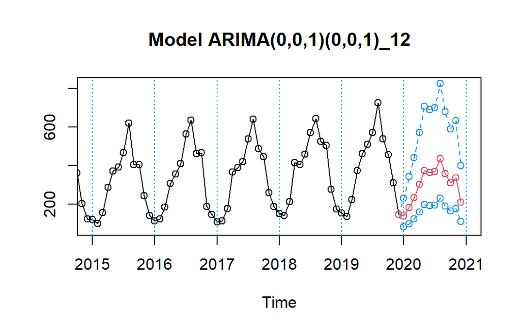

Se observa que la predicción en un tiempo extrapolable al de los datos sigue el mismo patrón que lo visto hasta el momento pero con una disminución en la tendencia lineal. Parece ser que se sigue el patron de los años anteriores pero en una escala mucho menor.

Por tanto, gracias a la predicción observada, se puede decir que ya se ha cumplido el objetivo principal del estudio.

# Conclusiones

Después de realizar las evaluaciones correspondientes y utilizar los métodos ya conocidos y mencionados con anterioridad, se concluye que la serie temporal correspondiente al número de pasajeros en el puerto de Barcelona se puede explicar como un modelo $MA(1)SMA(1)_{12}$.

Para llegar a esta conclusión ha sido necesario transformar la serie original con el fin de convertirla en una serie estacionaria. Para ello, se ha debido de aplicar una transformación logarítmica y hacer una diferenciación regular y otra estacional. Una vez conseguida la serie en el formato deseado, se han identificado 4 posibles modelos que podrían encajar con los datos estudiados, aunque dos de ellos han sido descartados por tener una medida de adecuación a los datos bastante inferiores en comparación al resto de opciones. Así pues, a los dos modelos resultantes, se les ha hecho una validación, se ha verificado su estabilidad y se ha observado su capacidad predictiva. A partir de los resultados obtenidos, se ha seleccionado un solo modelo, el mejor de ellos, el cual ha resultado ser un $MA(1)SMA(1)_{12}$. Este modelo tenía un AIC igual a -203.7712, un error de predicción de 28.5% y 25.7% en los casos de EQM y EAM, respectivamente y una amplitud de predicción de 408.5.

# Anexo

**#Aplicación empírica**

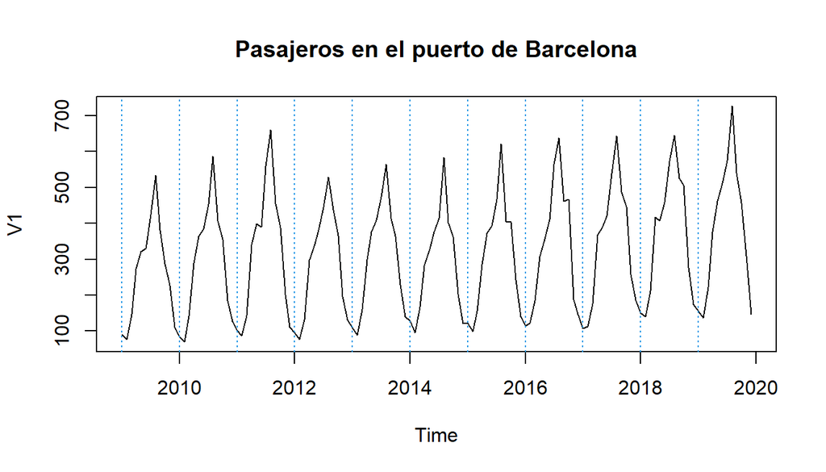

```r
serie=window(ts(read.table("PasajeBCN.dat"),start=1997,freq=12),start=2009)
plot(serie, main = "Pasajeros en el puerto de Barcelona")
abline(v = 2009:2019, col = 4, lty = 3)
```

**##Identificación del modelo**

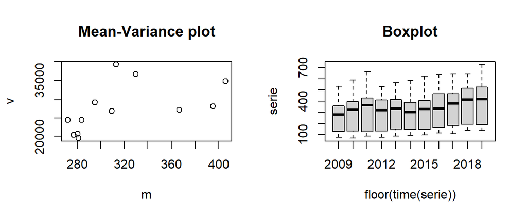

```r
par(mfrow=c(1,2))

m = apply(matrix(serie,ncol=12),2,mean)
v = apply(matrix(serie,ncol=12),2,var)
plot(v~m,main="Mean-Variance plot")

boxplot(serie~floor(time(serie)), main = "Boxplot")
```

```r
lnserie=log(serie)
plot(lnserie,type="o")
```

```r
monthplot(lnserie)
```

```r
d12lnserie<-diff(lnserie,lag=12)
```

```r
monthplot(d12lnserie)
```

```r
plot(d12lnserie,main="d12lnserie")
abline(h=0)
abline(h=mean(d12lnserie), col=2)
```

```r
d1d12lnserie <- diff(d12lnserie)
```

```r
plot(d1d12lnserie,main="d1d12lnserie")
abline(h=0)
abline(h=mean(d1d12lnserie), col=2)
```

```r
v1 <- var(lnserie)
v2 <- var(d12lnserie)
v3 <- var(d1d12lnserie)
```

```r
par(mfrow=c(1,2))

acf(d1d12lnserie,ylim=c(-1,1),lag.max=60,col=c(2,rep(1,11)),lwd=2)
pacf(d1d12lnserie,ylim=c(-1,1),lag.max=60,col=c(rep(1,11), 2),lwd=2)
```

**##Estimación de los modelos**

```r
mod1A = arima(d1d12lnserie, order = c(0,0,1), seasonal = list(order = c(0,0,1), period=12))
```

```r
mod1B = arima(lnserie, order = c(0,1,1), seasonal = list(order = c(0,1,1), period=12))
```

```r
mod2A = arima(d1d12lnserie, order = c(2,0,0), seasonal = list(order = c(0,0,1), period=12))
```

```r
mod2B = arima(lnserie, order = c(2,1,0), seasonal = list(order = c(0,1,1), period=12))
```

```r
mod3A = arima(d1d12lnserie, order = c(0,0,1), seasonal = list(order = c(1,0,0), period=12))
```

```r
mod3B = arima(lnserie, order = c(0,1,1), seasonal = list(order = c(1,1,0), period=12))
```

```r
mod4A = arima(d1d12lnserie, order = c(2,0,0), seasonal = list(order = c(1,0,0), period=12))
```

```r
mod4B = arima(lnserie, order = c(2,1,0), seasonal = list(order = c(1,1,0), period=12))
```

```r
#install.packages("stargazer")
library("stargazer")
stargazer(mod1A, mod2A, mod3A, mod4A, title="Results", type="text", notes.append = FALSE, report = "vtc",
notes = c("t = T-statistic value = coeff/SE(coeff)"), digits = 3,  column.labels = c("1A","2A","3A","4A"))
```

```
##
## Results
## =============================================================
##                               Dependent variable:
##                   -------------------------------------------
##                                  d1d12lnserie
##                       1A         2A         3A         4A
##                      (1)        (2)        (3)        (4)
## -------------------------------------------------------------
## ma1               t = -7.136            t = -7.262
##                     -0.673                -0.679
##
## ar1                          t = -6.641            t = -7.038
##                                -0.614                -0.642
##
## ar2                          t = -2.347            t = -2.611
##                                -0.220                -0.239
##
## sma1              t = -6.585 t = -5.949
##                     -0.620     -0.593
##
## sar1                                    t = -4.506 t = -4.468
##                                           -0.407     -0.404
##
## intercept         t = -0.027 t = -0.044 t = -0.146 t = -0.093
##                    -0.00004   -0.0001    -0.0003    -0.0003
##
## -------------------------------------------------------------
## Observations         119        119        119        119
## Log Likelihood     105.886    104.582    101.961    101.402
## sigma2              0.009      0.010      0.010      0.010
## Akaike Inf. Crit.  -203.771   -199.163   -195.923   -192.804
## =============================================================
## Note:                 t = T-statistic value = coeff/SE(coeff)
```

**#Validación de los modelos ajustados**

```r
validation_grafic <- function(model, dades){

s = frequency(get(model$series))
resid = model$residuals
par(mfrow = c(2, 2), mar = c(3, 3, 3, 3))
#Residuals plot
par(mfrow=c(1,2))
plot(resid, main = "Residuals")
abline(h = 0)
abline(h = c(-3*sd(resid, na.rm = T), 3*sd(resid, na.rm = T)), lty = 3, col = 4)
#Square Root of absolute values of residuals (Homocedasticity)
scatter.smooth(sqrt(abs(resid)), main = "Square Root of Absolute residuals",
lpars = list(col = 2))
#Normal plot of residuals
par(mfrow=c(1,2))
qqnorm(resid)
qqline(resid, col = 2, lwd = 2)
#Histogram of residuals with normal curve
hist(resid, breaks = 20, freq = F)
curve(dnorm(x, mean = mean(resid, na.rm = T), sd = sd(resid, na.rm = T)), col = 2, add = T)
}
```

```r
validation_test_homoce <- function(model, dades){
suppressMessages(require(lmtest, quietly = TRUE, warn.conflicts = FALSE))
##Breusch-Pagan test (vs. order)
obs = get(model$series)
print(bptest(resid(model)~I(1:length(resid(model)))))
##Breusch-Pagan test (vs. predictions)
obs = get(model$series)
print(bptest(resid(model)~I(obs-resid(model))))
}
```

```r
validation_test_normal <- function(model, dades){

##Shapiro-Wilks Normality test
print(shapiro.test(resid(model)))
suppressMessages(require(nortest, quietly = TRUE, warn.conflicts = FALSE))
##Anderson-Darling test
print(ad.test(resid(model)))
suppressMessages(require(tseries, quietly = TRUE, warn.conflicts = FALSE))
##Jarque-Bera test
print(jarque.bera.test(na.omit(c(resid(model)))))
}
```

```r
validation_test_indepen <- function(model, dades){
s = frequency(get(model$series))
resid = model$residuals

##Durbin-Watson test
print(dwtest(resid(model)~I(1:length(resid(model)))))
##Ljung-Box test
cat("\nLjung-Box test\n")
print(t(apply(matrix(c(1:4, (1:4)*s)), 1, function(el) {
te = Box.test(resid(model), type = "Ljung-Box", lag = el)
c(lag = (te$parameter), statistic = te$statistic[[1]], p.value = te$p.value)})))
}
```

```r
validation_acf_pacf <- function(model, dades){
  s = frequency(get(model$series))
  resid = model$residuals
  #ACF & PACF of residuals
  par(mfrow=c(1,2))
  acf(resid,ylim=c(-1,1),lag.max=60,col=c(2,rep(1,s-1)),lwd=1)
  pacf(resid,ylim=c(-1,1),lag.max=60,col=c(rep(1,s-1),2),lwd=1)
  par(mfrow=c(1,1))

  #ACF & PACF of square residuals
  par(mfrow=c(1,2))
  acf(resid^2,ylim=c(-1,1),lag.max=60,col=c(2,rep(1,s-1)),lwd=1)
  pacf(resid^2,ylim=c(-1,1),lag.max=60,col=c(rep(1,s-1),2),lwd=1)
  par(mfrow=c(1,1))
}
```

**##Validación modelo 1A**

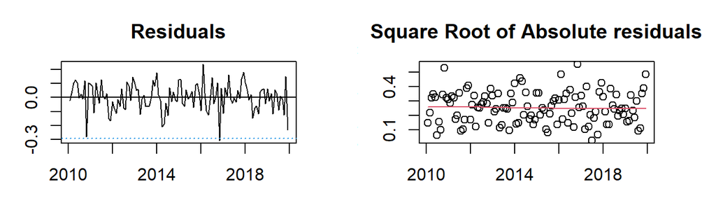

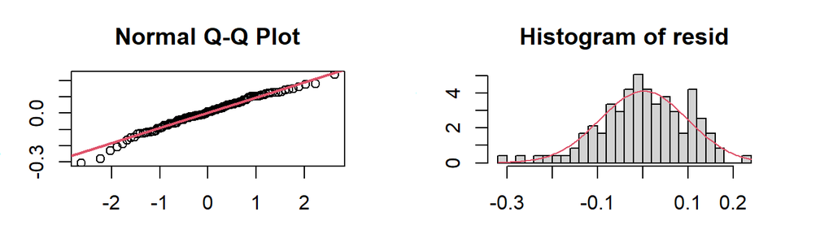

```r
model = mod1A
validation_grafic(model)
```

```r
validation_test_homoce(model)
```

[output not shown]

```r
validation_test_normal(model)
```

[output not shown]

```r
validation_test_indepen(model)
```

[output not shown]

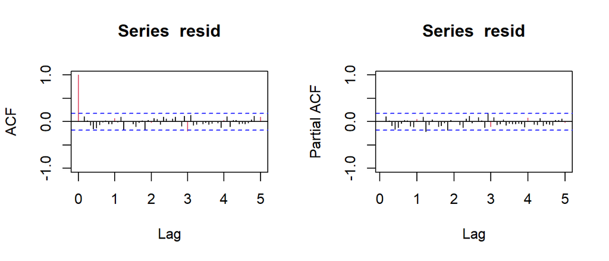

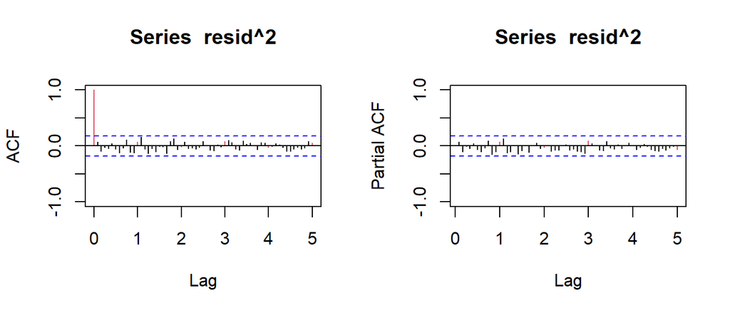

```r
validation_acf_pacf(model)
```

**##Validación modelo 2A**

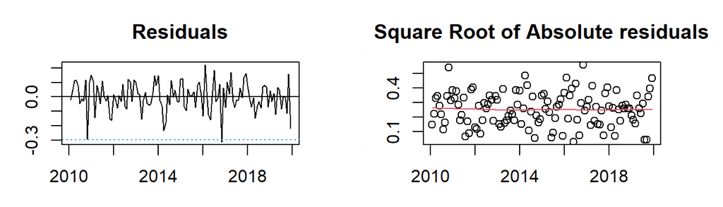

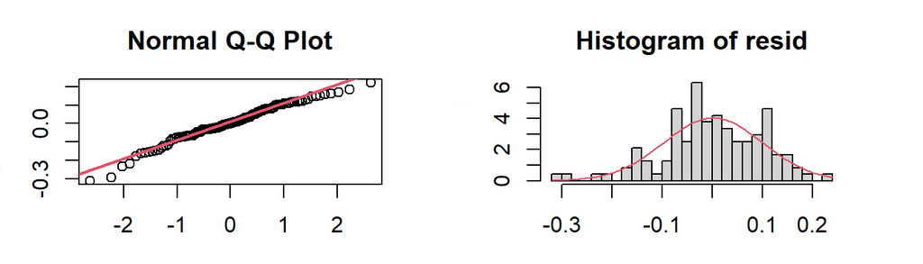

```r
model = mod2A
validation_grafic(model)
```

```r
validation_test_homoce(model)
```

[output not shown]

```r
validation_test_normal(model)
```

[output not shown]

```r
validation_test_indepen(model)
```

[output not shown]

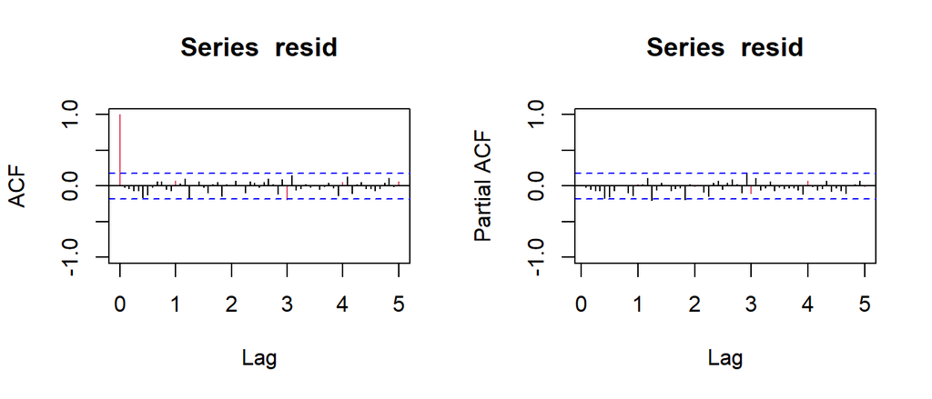

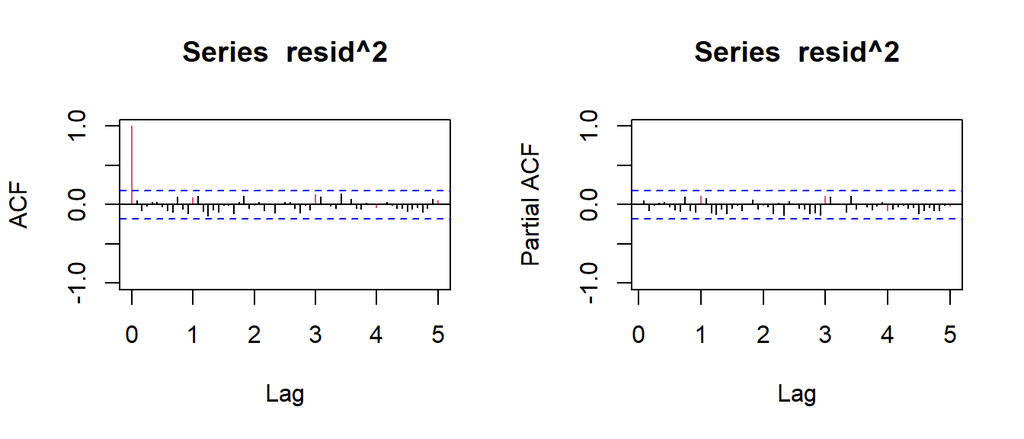

```r
validation_acf_pacf(model)
```

**#Predicción de modelos ARIMA ajustados y validados**

```r
ultim = c(2018,12)                       #Dic 2018
serie1 = window(serie, end = ultim + c(1,0))  #complete series: 2009-2019
lnserie1 = log(serie1)                   #log transformed
serie2 = window(serie, end = ultim)         #series without last year obsrvations: 2009-2018
lnserie2 = log(serie2)                   #log transformed
```

**##Modelo 1A**

```r
# Fit the model to the complete series: lnserie1
(mod1A2 = arima(lnserie1, order = c(0,0,1), seasonal = list(order = c(0,0,1), period=12)))
#Fit the model to the subset series (without 2019 data): lnserie2
(mod1A22 = arima(lnserie2,order = c(0,0,1), seasonal = list(order = c(0,0,1), period=12)))
```